# Extra Visualizations and Analyses

Dylan Glave

11/18/2021

## R Markdown

OK, so!

In our `full_analysis.Rmd` there is a TON of semi-related work. Some of that work (although great) is superfluous to the Cluster Analysis focus. In order to keep things organized, I’ll be moving chunks of that Rmd to…..you guessed it, this one!

Starting with the Bar Plots for each Engagement and Agreement question. **The relevant data is stored in `scaled_sum.csv`**

###### Reading in the data mentioned above

###### Bar Graphs for each A & E Question

**Engagement**

1. Question 44

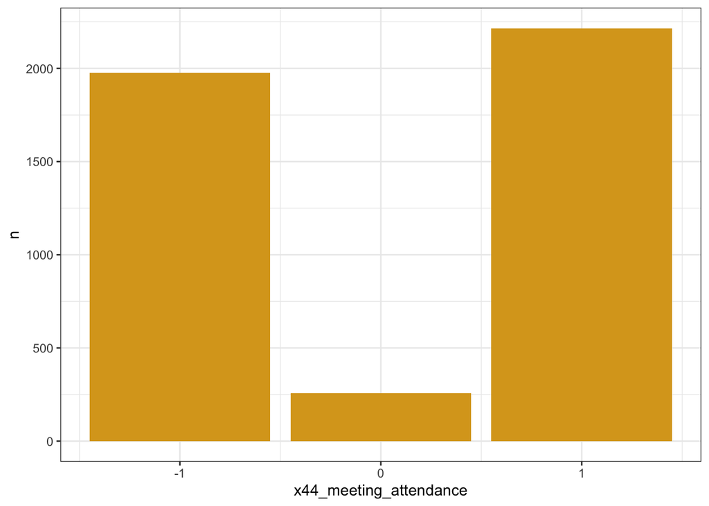

```r
x44_counts <- scaled_sum %>%
 count(x44_meeting_attendance)

ggplot(data = x44_counts,
       aes(x = x44_meeting_attendance, y = n)) +
 geom_bar( stat="identity", fill="goldenrod") +
  theme_bw()
```

**Question 45**

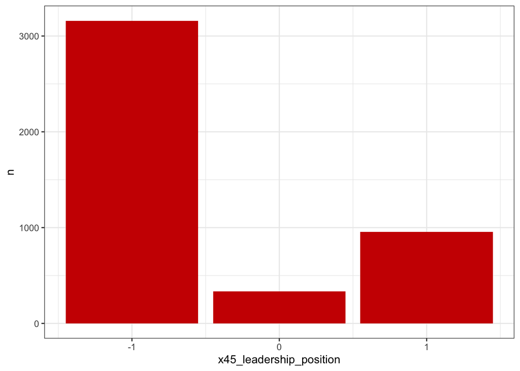

```r
x45_counts <- scaled_sum %>%
 count(x45_leadership_position)

ggplot(data = x45_counts,
       aes(x = x45_leadership_position, y = n)) +
 geom_bar( stat="identity", fill="red3") +
  theme_bw()
```

**Question 48**

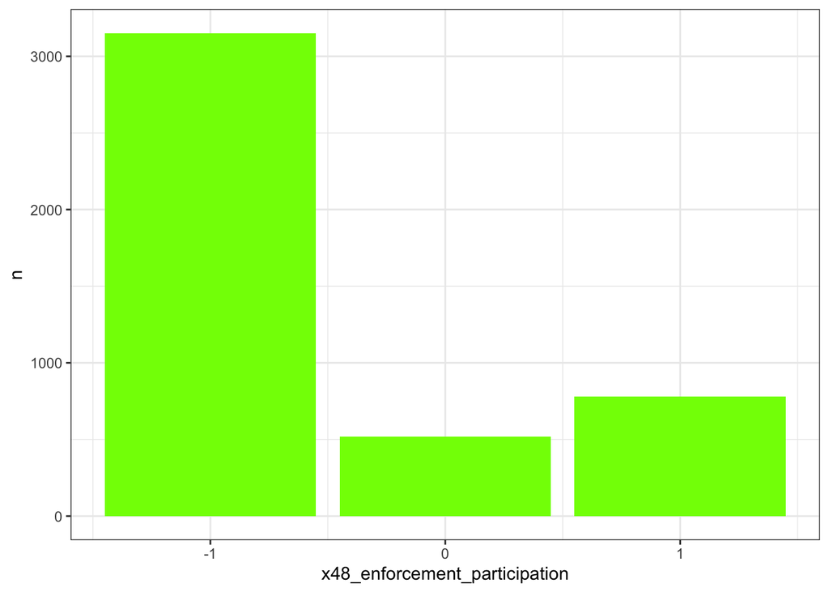

```r
x48_counts <- scaled_sum %>%
 count(x48_enforcement_participation)

ggplot(data = x48_counts,
       aes(x = x48_enforcement_participation, y = n)) +
 geom_bar( stat="identity", fill="chartreuse1") +
  theme_bw()
```

A quick pause from graphs!

Let’s see the combination counts for question 45 and 48

```r
counts_45_48 <- scaled_sum %>%
  count(x45_leadership_position, x48_enforcement_participation)
```

- Leaders who don’t enforce: 192
- Enforcement volunteers without leadership roles: 250
- Households who do both: 283 -Households who no neither: 1770

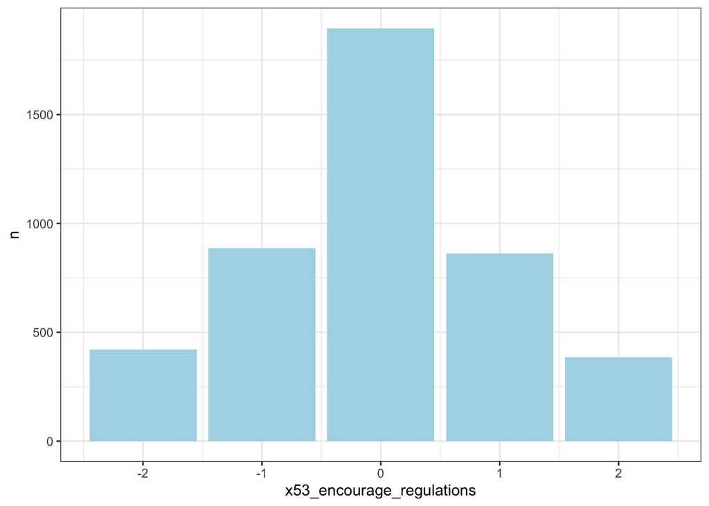

```r
x53_counts <- scaled_sum %>%
 count(x53_encourage_regulations)

ggplot(data = x53_counts,
       aes(x = x53_encourage_regulations, y = n)) +
 geom_bar( stat="identity", fill="lightblue") +
  theme_bw()
```

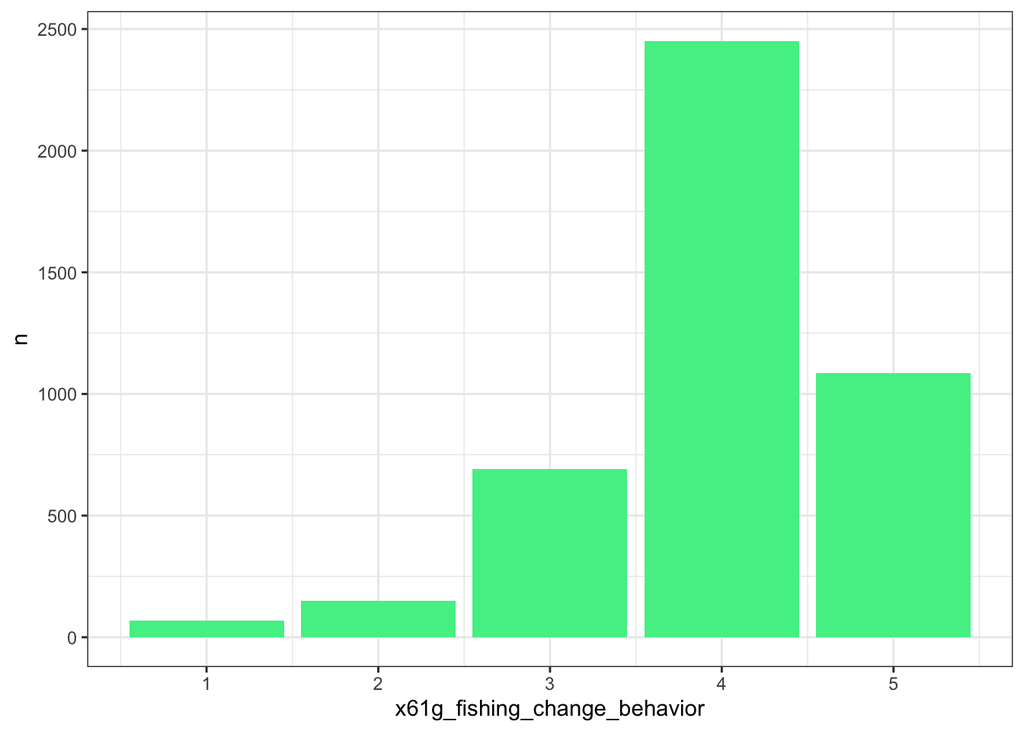

```r
x61g_counts <- scaled_sum %>%
 count(x61g_fishing_change_behavior)

ggplot(data = x61g_counts,
       aes(x = x61g_fishing_change_behavior, y = n)) +
 geom_bar( stat="identity", fill="seagreen2") +
  theme_bw()
```

*Question 61(g) mean = 3.955. This is the first mean that really skews high. With a mode of 4, most respondents were at least “willing” to change their fishing behavior for the reserve structure.*

Here’s a check for normal distrbution: It looks pretty normal, even with the high amount of “4” responses

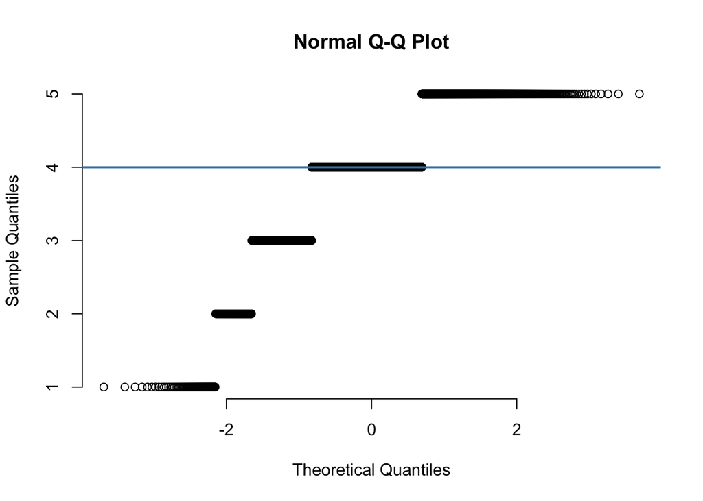

```r
qqnorm(scaled_sum$x61g_fishing_change_behavior, pch = 1, frame = FALSE)
qqline(scaled_sum$x61g_fishing_change_behavior, col = "steelblue", lwd = 2)
```

*Moving onto Agreement*

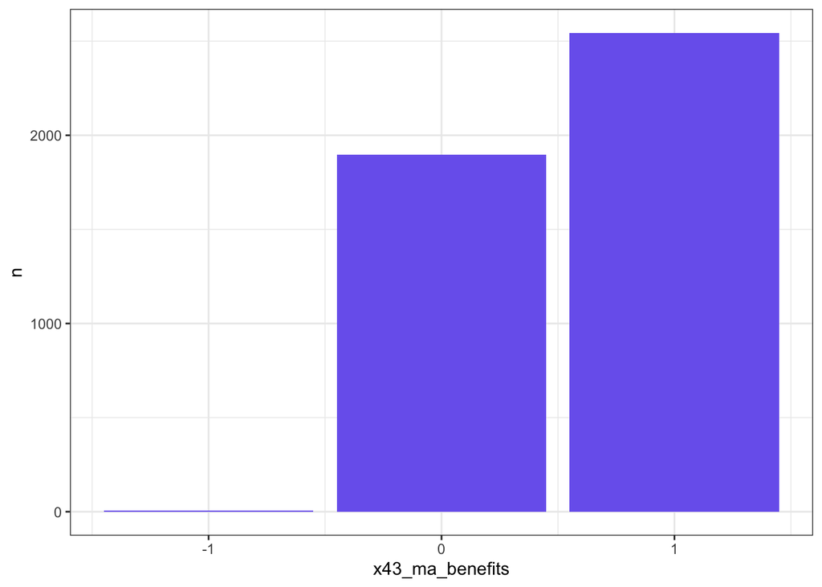

```r
x43_counts <- scaled_sum %>%
 count(x43_ma_benefits)

ggplot(data = x43_counts,
       aes(x = x43_ma_benefits, y = n)) +
 geom_bar( stat="identity", fill="slateblue2") +
  theme_bw()
```

*43: Mean = 0.556. Nearly no one answered with the negative response.*

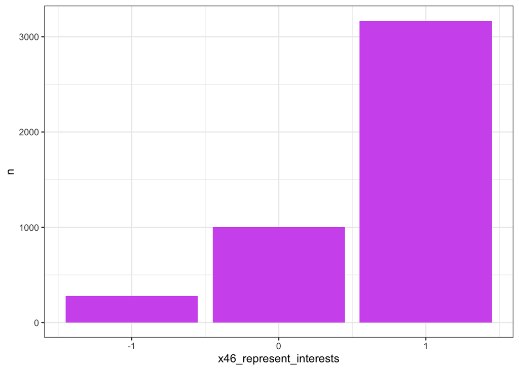

```r
x46_counts <- scaled_sum %>%
 count(x46_represent_interests)

ggplot(data = x46_counts,
       aes(x = x46_represent_interests, y = n)) +
 geom_bar( stat="identity", fill="mediumorchid2") +
  theme_bw()
```

*Question 46: Mean = 0.667. Huge skew towards the positive response.

We saw that variables 46 and 47 are highly correlated, and have similar wording. We find them to NOT be independent from one another, and exclude 47 from the index of Agreement.

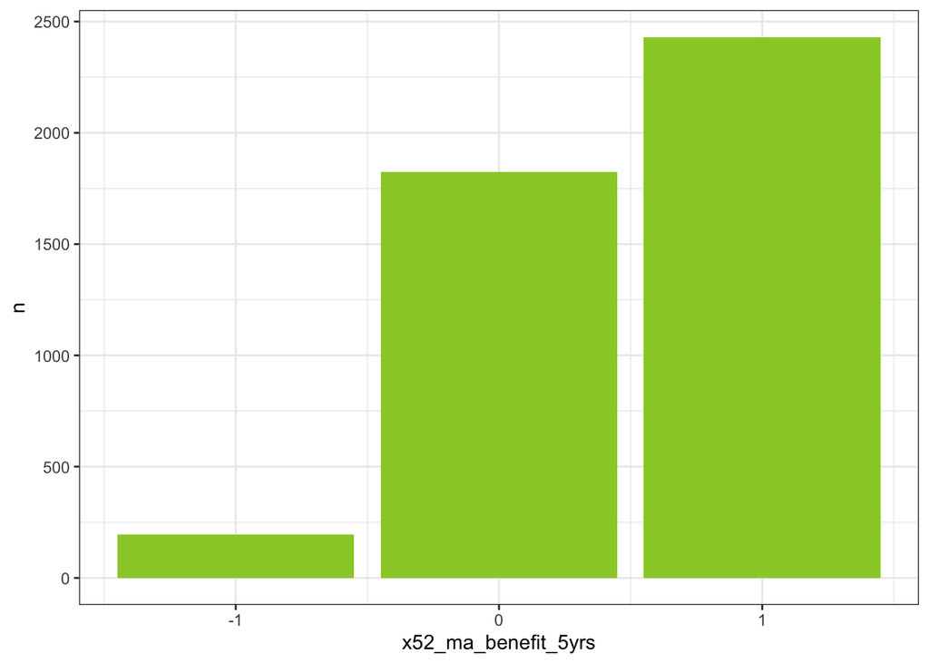

```r
x52_counts <- scaled_sum %>%
 count(x52_ma_benefit_5yrs)

ggplot(data = x52_counts,
       aes(x = x52_ma_benefit_5yrs  , y = n)) +
 geom_bar( stat="identity", fill="olivedrab3") +
  theme_bw()
```

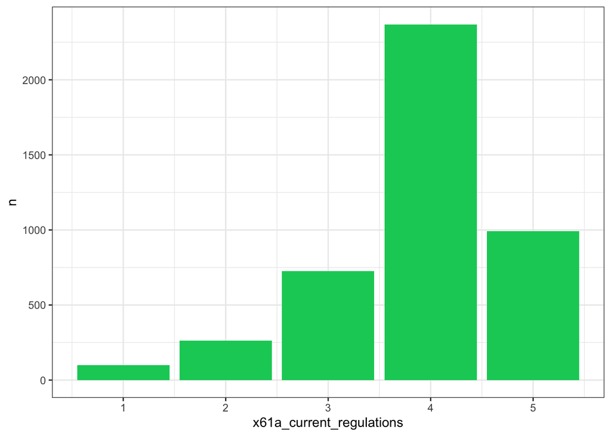

```r
x61a_counts <- scaled_sum %>%
 count(x61a_current_regulations)

ggplot(data = x61a_counts,
       aes(x = x61a_current_regulations, y = n)) +
 geom_bar( stat="identity", fill="springgreen3") +
  theme_bw()
```

*Question 61(a): Mean = 3.93, clear positive skew, and the mean seems to represent the mode and median*

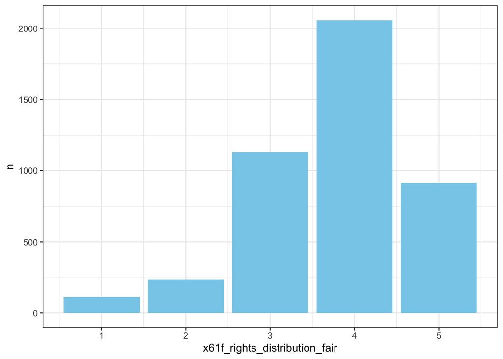

```r
x61f_counts <- scaled_sum %>%
 count(x61f_rights_distribution_fair)

ggplot(data = x61f_counts,
       aes(x =x61f_rights_distribution_fair, y = n)) +
 geom_bar( stat="identity", fill="skyblue") +
  theme_bw()
```

*61(f): Mean = 3.805. More neutral responses that strongly agree, but very few disagreeing fishers.*

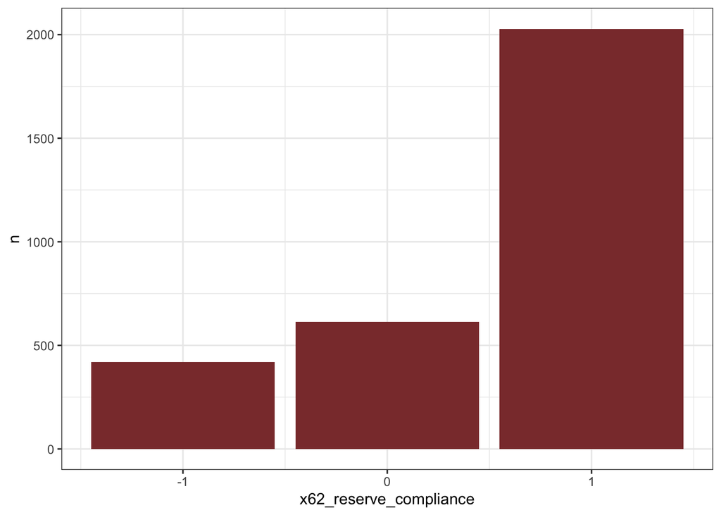

```r
x62_counts <- scaled_sum %>%
 count(x62_reserve_compliance)

ggplot(data = x62_counts,
       aes(x =x62_reserve_compliance, y = n)) +
 geom_bar( stat="identity", fill="indianred4") +
  theme_bw()
```

Question 62: Mean = 0.525

We do NOT include this question in the index, but will use it to create a graph of “admitting noncompliance”

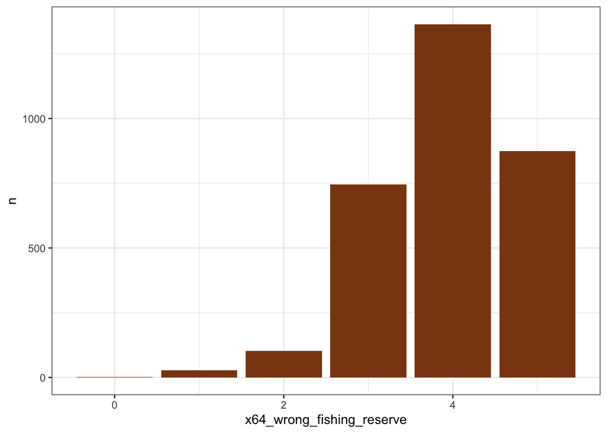

```r
x64_counts <- scaled_sum %>%
 count(x64_wrong_fishing_reserve)

ggplot(data = x64_counts,
       aes(x =x64_wrong_fishing_reserve, y = n)) +
 geom_bar( stat="identity", fill="chocolate4") +
  theme_bw()
```

*Question 64: Mean = 3.957. Another mean between 3 and 4, with very small numbers of below-neutral responses*